# Risk Factor Analysis

## Outcome Variable

**Outcome Variable:** y_rate_len

## Predictor Variables

**Intervention Variable:** parity

**Adjustment Set:**

- arm
- W_mage
- meducyrs
- feducyrs
- hhwealth_quart
- W_mhtcm
- vagbrth
- W_nrooms
- impsan
- delta_W_mage
- delta_meducyrs
- delta_feducyrs
- delta_hhwealth_quart
- delta_W_mhtcm
- delta_vagbrth
- delta_W_nrooms
- delta_impsan

## Stratifying Variables

The analysis was stratified on these variable(s):

- agecat
- studyid
- country

## Data Summary

| agecat | studyid | country | parity | n_cell | n |
| --- | --- | --- | --- | --- | --- |
| 0-3 months | ki1017093b-PROVIDE | BANGLADESH | 1 | 240 | 634 |
| 0-3 months | ki1017093b-PROVIDE | BANGLADESH | 2 | 225 | 634 |
| 0-3 months | ki1017093b-PROVIDE | BANGLADESH | 3+ | 169 | 634 |
| 0-3 months | kiGH5241-JiVitA-3 | BANGLADESH | 1 | 6375 | 20028 |
| 0-3 months | kiGH5241-JiVitA-3 | BANGLADESH | 2 | 6945 | 20028 |
| 0-3 months | kiGH5241-JiVitA-3 | BANGLADESH | 3+ | 6708 | 20028 |
| 0-3 months | ki1101329-Keneba | GAMBIA | 1 | 130 | 1145 |
| 0-3 months | ki1101329-Keneba | GAMBIA | 2 | 113 | 1145 |
| 0-3 months | ki1101329-Keneba | GAMBIA | 3+ | 902 | 1145 |
| 0-3 months | ki1135781-COHORTS | GUATEMALA | 1 | 93 | 728 |
| 0-3 months | ki1135781-COHORTS | GUATEMALA | 2 | 111 | 728 |
| 0-3 months | ki1135781-COHORTS | GUATEMALA | 3+ | 524 | 728 |
| 0-3 months | ki1000304b-SAS-CompFeed | INDIA | 1 | 313 | 1168 |
| 0-3 months | ki1000304b-SAS-CompFeed | INDIA | 2 | 280 | 1168 |
| 0-3 months | ki1000304b-SAS-CompFeed | INDIA | 3+ | 575 | 1168 |
| 0-3 months | ki1135781-COHORTS | INDIA | 1 | 671 | 4021 |
| 0-3 months | ki1135781-COHORTS | INDIA | 2 | 1015 | 4021 |
| 0-3 months | ki1135781-COHORTS | INDIA | 3+ | 2335 | 4021 |
| 0-3 months | ki1126311-ZVITAMBO | ZIMBABWE | 1 | 3052 | 7863 |
| 0-3 months | ki1126311-ZVITAMBO | ZIMBABWE | 2 | 2438 | 7863 |
| 0-3 months | ki1126311-ZVITAMBO | ZIMBABWE | 3+ | 2373 | 7863 |
| 3-6 months | ki1017093b-PROVIDE | BANGLADESH | 1 | 206 | 574 |
| 3-6 months | ki1017093b-PROVIDE | BANGLADESH | 2 | 211 | 574 |
| 3-6 months | ki1017093b-PROVIDE | BANGLADESH | 3+ | 157 | 574 |
| 3-6 months | kiGH5241-JiVitA-3 | BANGLADESH | 1 | 4401 | 12573 |
| 3-6 months | kiGH5241-JiVitA-3 | BANGLADESH | 2 | 4359 | 12573 |
| 3-6 months | kiGH5241-JiVitA-3 | BANGLADESH | 3+ | 3813 | 12573 |
| 3-6 months | ki1101329-Keneba | GAMBIA | 1 | 146 | 1130 |
| 3-6 months | ki1101329-Keneba | GAMBIA | 2 | 107 | 1130 |
| 3-6 months | ki1101329-Keneba | GAMBIA | 3+ | 877 | 1130 |

[output cut: 77 more lines]

The following strata were considered:

- agecat: 0-3 months, studyid: ki1000304b-SAS-CompFeed, country: INDIA
- agecat: 0-3 months, studyid: ki1017093b-PROVIDE, country: BANGLADESH
- agecat: 0-3 months, studyid: ki1101329-Keneba, country: GAMBIA
- agecat: 0-3 months, studyid: ki1126311-ZVITAMBO, country: ZIMBABWE
- agecat: 0-3 months, studyid: ki1135781-COHORTS, country: GUATEMALA
- agecat: 0-3 months, studyid: ki1135781-COHORTS, country: INDIA
- agecat: 0-3 months, studyid: kiGH5241-JiVitA-3, country: BANGLADESH
- agecat: 12-24 months, studyid: ki1017093b-PROVIDE, country: BANGLADESH
- agecat: 12-24 months, studyid: ki1066203-TanzaniaChild2, country: TANZANIA, UNITED REPUBLIC OF
- agecat: 12-24 months, studyid: ki1101329-Keneba, country: GAMBIA
- agecat: 12-24 months, studyid: ki1113344-GMS-Nepal, country: NEPAL
- agecat: 12-24 months, studyid: ki1126311-ZVITAMBO, country: ZIMBABWE
- agecat: 12-24 months, studyid: ki1135781-COHORTS, country: GUATEMALA
- agecat: 12-24 months, studyid: ki1135781-COHORTS, country: INDIA
- agecat: 12-24 months, studyid: ki1135781-COHORTS, country: PHILIPPINES
- agecat: 12-24 months, studyid: kiGH5241-JiVitA-3, country: BANGLADESH
- agecat: 3-6 months, studyid: ki1000304b-SAS-CompFeed, country: INDIA
- agecat: 3-6 months, studyid: ki1017093b-PROVIDE, country: BANGLADESH
- agecat: 3-6 months, studyid: ki1066203-TanzaniaChild2, country: TANZANIA, UNITED REPUBLIC OF
- agecat: 3-6 months, studyid: ki1101329-Keneba, country: GAMBIA
- agecat: 3-6 months, studyid: ki1113344-GMS-Nepal, country: NEPAL
- agecat: 3-6 months, studyid: ki1126311-ZVITAMBO, country: ZIMBABWE
- agecat: 3-6 months, studyid: ki1135781-COHORTS, country: GUATEMALA
- agecat: 3-6 months, studyid: ki1135781-COHORTS, country: INDIA
- agecat: 3-6 months, studyid: kiGH5241-JiVitA-3, country: BANGLADESH
- agecat: 6-12 months, studyid: ki1000304b-SAS-CompFeed, country: INDIA
- agecat: 6-12 months, studyid: ki1000304b-SAS-FoodSuppl, country: INDIA
- agecat: 6-12 months, studyid: ki1017093b-PROVIDE, country: BANGLADESH
- agecat: 6-12 months, studyid: ki1066203-TanzaniaChild2, country: TANZANIA, UNITED REPUBLIC OF
- agecat: 6-12 months, studyid: ki1101329-Keneba, country: GAMBIA
- agecat: 6-12 months, studyid: ki1113344-GMS-Nepal, country: NEPAL
- agecat: 6-12 months, studyid: ki1126311-ZVITAMBO, country: ZIMBABWE
- agecat: 6-12 months, studyid: ki1135781-COHORTS, country: GUATEMALA
- agecat: 6-12 months, studyid: ki1135781-COHORTS, country: INDIA
- agecat: 6-12 months, studyid: ki1135781-COHORTS, country: PHILIPPINES
- agecat: 6-12 months, studyid: kiGH5241-JiVitA-3, country: BANGLADESH

### Dropped Strata

Some strata were dropped due to rare outcomes:

- agecat: 12-24 months, studyid: ki1066203-TanzaniaChild2, country: TANZANIA, UNITED REPUBLIC OF

## Methods Detail

We’re interested in the causal parameters $E[Y_a]$ for all values of $a \in \mathcal{A}$. These parameters represent the mean outcome if, possibly contrary to fact, we intervened to set all units to have $A=a$. Under the randomization and positivity assumptions, these are identified by the statistical parameters $\psi_a=E_W[E_{Y|A,W}(Y|A=a,W)]$. In addition, we’re interested in the mean of $Y$, $E[Y]$ under no intervention (the observed mean). We will estimate these parameters by using SuperLearner to fit the relevant likelihood factors – $E_{Y|A,W}(Y|A=a,W)$ and $p(A=a|W)$, and then updating our likelihood fit using a joint TMLE.

For unadjusted analyses ($W=\{\}$), initial likelihoods were estimated using Lrnr_glm to estimate the simple $E(Y|A)$ and Lrnr_mean to estimate $p(A)$. For adjusted analyses, a small library containing Lrnr_glmnet, Lrnr_xgboost, and Lrnr_mean was used.

Having estimated these parameters, we will then use the delta method to estimate relative risks and attributable risks relative to a prespecified baseline level of $A$.

# Results Detail

## Results Plots

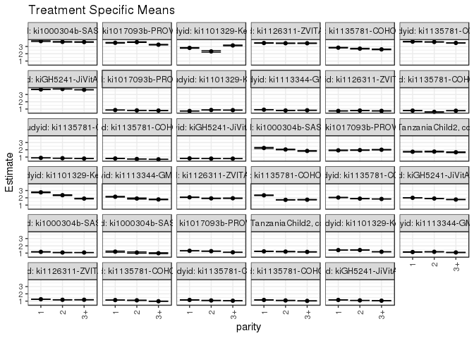

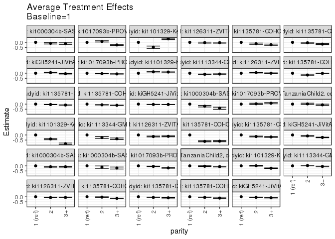

## Results Table

### Parameter: TSM

| agecat | studyid | country | intervention_level | baseline_level | estimate | ci_lower | ci_upper |
| --- | --- | --- | --- | --- | --- | --- | --- |
| 0-3 months | ki1000304b-SAS-CompFeed | INDIA | 1 | NA | 3.7347772 | 3.6892557 | 3.7802987 |
| 0-3 months | ki1000304b-SAS-CompFeed | INDIA | 2 | NA | 3.6344904 | 3.5913888 | 3.6775920 |
| 0-3 months | ki1000304b-SAS-CompFeed | INDIA | 3+ | NA | 3.6130598 | 3.5711590 | 3.6549605 |
| 0-3 months | ki1017093b-PROVIDE | BANGLADESH | 1 | NA | 3.5063522 | 3.4623176 | 3.5503867 |
| 0-3 months | ki1017093b-PROVIDE | BANGLADESH | 2 | NA | 3.5967954 | 3.5533427 | 3.6402482 |
| 0-3 months | ki1017093b-PROVIDE | BANGLADESH | 3+ | NA | 3.2469966 | 3.2066598 | 3.2873334 |
| 0-3 months | ki1101329-Keneba | GAMBIA | 1 | NA | 2.8018716 | 2.7525329 | 2.8512102 |
| 0-3 months | ki1101329-Keneba | GAMBIA | 2 | NA | 2.3240813 | 2.2169451 | 2.4312175 |
| 0-3 months | ki1101329-Keneba | GAMBIA | 3+ | NA | 3.1418641 | 3.0900817 | 3.1936464 |
| 0-3 months | ki1126311-ZVITAMBO | ZIMBABWE | 1 | NA | 3.4766076 | 3.4419407 | 3.5112746 |
| 0-3 months | ki1126311-ZVITAMBO | ZIMBABWE | 2 | NA | 3.4472380 | 3.4110272 | 3.4834488 |
| 0-3 months | ki1126311-ZVITAMBO | ZIMBABWE | 3+ | NA | 3.4437391 | 3.4097284 | 3.4777499 |
| 0-3 months | ki1135781-COHORTS | GUATEMALA | 1 | NA | 2.8347465 | 2.7942372 | 2.8752558 |
| 0-3 months | ki1135781-COHORTS | GUATEMALA | 2 | NA | 2.7017922 | 2.6525174 | 2.7510670 |
| 0-3 months | ki1135781-COHORTS | GUATEMALA | 3+ | NA | 2.6020078 | 2.5547993 | 2.6492163 |
| 0-3 months | ki1135781-COHORTS | INDIA | 1 | NA | 3.6656993 | 3.6259132 | 3.7054855 |
| 0-3 months | ki1135781-COHORTS | INDIA | 2 | NA | 3.6238992 | 3.5908239 | 3.6569746 |
| 0-3 months | ki1135781-COHORTS | INDIA | 3+ | NA | 3.4899419 | 3.4657876 | 3.5140962 |
| 0-3 months | kiGH5241-JiVitA-3 | BANGLADESH | 1 | NA | 3.6970500 | 3.6718311 | 3.7222688 |
| 0-3 months | kiGH5241-JiVitA-3 | BANGLADESH | 2 | NA | 3.7568051 | 3.7397697 | 3.7738405 |
| 0-3 months | kiGH5241-JiVitA-3 | BANGLADESH | 3+ | NA | 3.6486171 | 3.6292762 | 3.6679579 |
| 3-6 months | ki1000304b-SAS-CompFeed | INDIA | 1 | NA | 2.2465320 | 2.1690640 | 2.3239999 |
| 3-6 months | ki1000304b-SAS-CompFeed | INDIA | 2 | NA | 2.0416482 | 1.9975113 | 2.0857852 |
| 3-6 months | ki1000304b-SAS-CompFeed | INDIA | 3+ | NA | 1.8423162 | 1.7905391 | 1.8940933 |
| 3-6 months | ki1017093b-PROVIDE | BANGLADESH | 1 | NA | 1.9230292 | 1.8794796 | 1.9665788 |
| 3-6 months | ki1017093b-PROVIDE | BANGLADESH | 2 | NA | 1.9536418 | 1.9175577 | 1.9897259 |
| 3-6 months | ki1017093b-PROVIDE | BANGLADESH | 3+ | NA | 2.0089824 | 1.9730773 | 2.0448874 |
| 3-6 months | ki1066203-TanzaniaChild2 | TANZANIA, UNITED REPUBLIC OF | 1 | NA | 1.7328495 | 1.6836757 | 1.7820232 |
| 3-6 months | ki1066203-TanzaniaChild2 | TANZANIA, UNITED REPUBLIC OF | 2 | NA | 1.7516623 | 1.6980259 | 1.8052987 |
| 3-6 months | ki1066203-TanzaniaChild2 | TANZANIA, UNITED REPUBLIC OF | 3+ | NA | 1.6600183 | 1.6104387 | 1.7095980 |

[output cut: 75 more lines]

### Parameter: E(Y)

| agecat | studyid | country | intervention_level | baseline_level | estimate | ci_lower | ci_upper |
| --- | --- | --- | --- | --- | --- | --- | --- |
| 0-3 months | ki1000304b-SAS-CompFeed | INDIA | NA | NA | 3.6019890 | 3.5739652 | 3.6300127 |
| 0-3 months | ki1017093b-PROVIDE | BANGLADESH | NA | NA | 3.4826706 | 3.4434873 | 3.5218539 |
| 0-3 months | ki1101329-Keneba | GAMBIA | NA | NA | 3.1454440 | 3.0949962 | 3.1958917 |
| 0-3 months | ki1126311-ZVITAMBO | ZIMBABWE | NA | NA | 3.3706450 | 3.3497515 | 3.3915385 |
| 0-3 months | ki1135781-COHORTS | GUATEMALA | NA | NA | 2.6117091 | 2.5680119 | 2.6554063 |
| 0-3 months | ki1135781-COHORTS | INDIA | NA | NA | 3.5339988 | 3.5157374 | 3.5522602 |
| 0-3 months | kiGH5241-JiVitA-3 | BANGLADESH | NA | NA | 3.7184743 | 3.7081281 | 3.7288205 |
| 3-6 months | ki1000304b-SAS-CompFeed | INDIA | NA | NA | 1.9406419 | 1.8967379 | 1.9845458 |
| 3-6 months | ki1017093b-PROVIDE | BANGLADESH | NA | NA | 1.9654454 | 1.9303798 | 2.0005110 |
| 3-6 months | ki1066203-TanzaniaChild2 | TANZANIA, UNITED REPUBLIC OF | NA | NA | 1.7963100 | 1.7603114 | 1.8323086 |
| 3-6 months | ki1101329-Keneba | GAMBIA | NA | NA | 1.9715566 | 1.9280386 | 2.0150747 |
| 3-6 months | ki1113344-GMS-Nepal | NEPAL | NA | NA | 1.7057418 | 1.6666784 | 1.7448052 |
| 3-6 months | ki1126311-ZVITAMBO | ZIMBABWE | NA | NA | 1.9747519 | 1.9548124 | 1.9946914 |
| 3-6 months | ki1135781-COHORTS | GUATEMALA | NA | NA | 1.7616932 | 1.7309393 | 1.7924472 |
| 3-6 months | ki1135781-COHORTS | INDIA | NA | NA | 1.8562696 | 1.8412447 | 1.8712944 |
| 3-6 months | kiGH5241-JiVitA-3 | BANGLADESH | NA | NA | 1.9201827 | 1.9097195 | 1.9306459 |
| 6-12 months | ki1000304b-SAS-CompFeed | INDIA | NA | NA | 1.0983052 | 1.0864567 | 1.1101538 |
| 6-12 months | ki1000304b-SAS-FoodSuppl | INDIA | NA | NA | 1.0139672 | 0.9374673 | 1.0904670 |
| 6-12 months | ki1017093b-PROVIDE | BANGLADESH | NA | NA | 1.1731762 | 1.1558671 | 1.1904853 |
| 6-12 months | ki1066203-TanzaniaChild2 | TANZANIA, UNITED REPUBLIC OF | NA | NA | 1.1968328 | 1.1751167 | 1.2185490 |
| 6-12 months | ki1101329-Keneba | GAMBIA | NA | NA | 1.1774049 | 1.1574133 | 1.1973966 |
| 6-12 months | ki1113344-GMS-Nepal | NEPAL | NA | NA | 1.1681560 | 1.1485303 | 1.1877817 |
| 6-12 months | ki1126311-ZVITAMBO | ZIMBABWE | NA | NA | 1.1980958 | 1.1871818 | 1.2090098 |
| 6-12 months | ki1135781-COHORTS | GUATEMALA | NA | NA | 1.0185507 | 1.0014002 | 1.0357013 |
| 6-12 months | ki1135781-COHORTS | INDIA | NA | NA | 1.0842179 | 1.0737055 | 1.0947303 |
| 6-12 months | ki1135781-COHORTS | PHILIPPINES | NA | NA | 1.0674471 | 1.0552459 | 1.0796483 |
| 6-12 months | kiGH5241-JiVitA-3 | BANGLADESH | NA | NA | 1.1069558 | 1.1002095 | 1.1137021 |
| 12-24 months | ki1017093b-PROVIDE | BANGLADESH | NA | NA | 0.8575519 | 0.8455586 | 0.8695452 |
| 12-24 months | ki1101329-Keneba | GAMBIA | NA | NA | 0.8449409 | 0.8333460 | 0.8565357 |
| 12-24 months | ki1113344-GMS-Nepal | NEPAL | NA | NA | 0.8378848 | 0.8224521 | 0.8533174 |
| 12-24 months | ki1126311-ZVITAMBO | ZIMBABWE | NA | NA | 0.7099126 | 0.6840087 | 0.7358165 |
| 12-24 months | ki1135781-COHORTS | GUATEMALA | NA | NA | 0.7793681 | 0.7685580 | 0.7901783 |
| 12-24 months | ki1135781-COHORTS | INDIA | NA | NA | 0.8139538 | 0.8077496 | 0.8201580 |
| 12-24 months | ki1135781-COHORTS | PHILIPPINES | NA | NA | 0.7067500 | 0.6994129 | 0.7140870 |
| 12-24 months | kiGH5241-JiVitA-3 | BANGLADESH | NA | NA | 0.7967251 | 0.7914074 | 0.8020427 |

### Parameter: ATE

| agecat | studyid | country | intervention_level | baseline_level | estimate | ci_lower | ci_upper |
| --- | --- | --- | --- | --- | --- | --- | --- |
| 0-3 months | ki1000304b-SAS-CompFeed | INDIA | 1 | 1 | 0.0000000 | 0.0000000 | 0.0000000 |
| 0-3 months | ki1000304b-SAS-CompFeed | INDIA | 2 | 1 | -0.1002868 | -0.1651203 | -0.0354532 |
| 0-3 months | ki1000304b-SAS-CompFeed | INDIA | 3+ | 1 | -0.1217174 | -0.1969161 | -0.0465188 |
| 0-3 months | ki1017093b-PROVIDE | BANGLADESH | 1 | 1 | 0.0000000 | 0.0000000 | 0.0000000 |
| 0-3 months | ki1017093b-PROVIDE | BANGLADESH | 2 | 1 | 0.0904433 | 0.0290035 | 0.1518831 |
| 0-3 months | ki1017093b-PROVIDE | BANGLADESH | 3+ | 1 | -0.2593556 | -0.3191455 | -0.1995656 |
| 0-3 months | ki1101329-Keneba | GAMBIA | 1 | 1 | 0.0000000 | 0.0000000 | 0.0000000 |
| 0-3 months | ki1101329-Keneba | GAMBIA | 2 | 1 | -0.4777903 | -0.5889624 | -0.3666182 |
| 0-3 months | ki1101329-Keneba | GAMBIA | 3+ | 1 | 0.3399925 | 0.2715309 | 0.4084541 |
| 0-3 months | ki1126311-ZVITAMBO | ZIMBABWE | 1 | 1 | 0.0000000 | 0.0000000 | 0.0000000 |
| 0-3 months | ki1126311-ZVITAMBO | ZIMBABWE | 2 | 1 | -0.0293696 | -0.0790322 | 0.0202929 |
| 0-3 months | ki1126311-ZVITAMBO | ZIMBABWE | 3+ | 1 | -0.0328685 | -0.0813395 | 0.0156025 |
| 0-3 months | ki1135781-COHORTS | GUATEMALA | 1 | 1 | 0.0000000 | 0.0000000 | 0.0000000 |
| 0-3 months | ki1135781-COHORTS | GUATEMALA | 2 | 1 | -0.1329543 | -0.1944152 | -0.0714934 |
| 0-3 months | ki1135781-COHORTS | GUATEMALA | 3+ | 1 | -0.2327387 | -0.2916726 | -0.1738048 |
| 0-3 months | ki1135781-COHORTS | INDIA | 1 | 1 | 0.0000000 | 0.0000000 | 0.0000000 |
| 0-3 months | ki1135781-COHORTS | INDIA | 2 | 1 | -0.0418001 | -0.0933317 | 0.0097315 |
| 0-3 months | ki1135781-COHORTS | INDIA | 3+ | 1 | -0.1757574 | -0.2221831 | -0.1293316 |
| 0-3 months | kiGH5241-JiVitA-3 | BANGLADESH | 1 | 1 | 0.0000000 | 0.0000000 | 0.0000000 |
| 0-3 months | kiGH5241-JiVitA-3 | BANGLADESH | 2 | 1 | 0.0597551 | 0.0300491 | 0.0894611 |
| 0-3 months | kiGH5241-JiVitA-3 | BANGLADESH | 3+ | 1 | -0.0484329 | -0.0806747 | -0.0161912 |
| 3-6 months | ki1000304b-SAS-CompFeed | INDIA | 1 | 1 | 0.0000000 | 0.0000000 | 0.0000000 |
| 3-6 months | ki1000304b-SAS-CompFeed | INDIA | 2 | 1 | -0.2048838 | -0.2802143 | -0.1295532 |
| 3-6 months | ki1000304b-SAS-CompFeed | INDIA | 3+ | 1 | -0.4042158 | -0.5078612 | -0.3005704 |
| 3-6 months | ki1017093b-PROVIDE | BANGLADESH | 1 | 1 | 0.0000000 | 0.0000000 | 0.0000000 |
| 3-6 months | ki1017093b-PROVIDE | BANGLADESH | 2 | 1 | 0.0306126 | -0.0251088 | 0.0863340 |
| 3-6 months | ki1017093b-PROVIDE | BANGLADESH | 3+ | 1 | 0.0859532 | 0.0307186 | 0.1411877 |
| 3-6 months | ki1066203-TanzaniaChild2 | TANZANIA, UNITED REPUBLIC OF | 1 | 1 | 0.0000000 | 0.0000000 | 0.0000000 |
| 3-6 months | ki1066203-TanzaniaChild2 | TANZANIA, UNITED REPUBLIC OF | 2 | 1 | 0.0188128 | -0.0528434 | 0.0904690 |
| 3-6 months | ki1066203-TanzaniaChild2 | TANZANIA, UNITED REPUBLIC OF | 3+ | 1 | -0.0728311 | -0.1419954 | -0.0036668 |

[output cut: 75 more lines]